# Documentation in Support of the 2024 Outside Lingcod Stock Assessment: Data, Models & Diagnostics

Tom Carruthers tom@bluematterscience.com

21 March, 2024

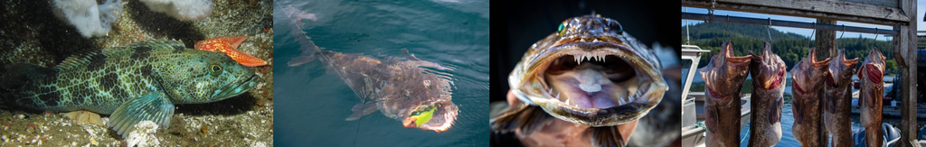

[figure not shown]

### Disclaimer

The following documentation is intended to support materials presented in the development and review of stock assessment models for outside lingcod.

Currently this work is preliminary and intended to elicit feedback on data, modelling and other aspects.

Any results that are presented are not final and are not necessarily relevant to future policy making.

### Objective

Develop a defensible and empirically based model of population and fishery dynamics to support management decision making for outside lingcod (Ophiodon elongatus) making use of data regarding, biology, catches, survey indices and catch-at-age compositions.

### Project Status

Following feedback from the Technical Working Group, a straw dog assessment model was updated to include the Triennial survey index. This updated model is first iteration of the Base Case assessment model, which is the basis for future senstivity analyses and diagnostic runs.

### Project details

| Term | Jan 1 2024 - March 31 2024 |
| --- | --- |
| Funding body | Fisheries and Oceans Canada |
| Funding stream | Standing Offer |
| Contract No. | 4600000482_001 |
| Project Partners | Blue Matter Science Ltd. |
| Blue Matter Team | Tom Carruthers, Quang Huynh |
| DFO Principal Investigator | Dana Haggarty |

### Presentations (.pdf)

Tech Team 1 - 22 Feb 2024 - Straw dog data and model

March Update 2024 - first Base Case model

### Straw Dog Assessment (22 Feb 2024)

Stock Synthesis HTML assessment reporting

### Base Case Assessment (21 March 2024)

Stock Synthesis HTML assessment reporting

### Software and Code

[pbs-assess / lingcod-outside repository (PRIVATE - email Dana.Haggarty@dfo-mpo.gc.ca for access)](https://github.com/pbs-assess/lingcod-outside)

[Stock Synthesis Manual](https://nmfs-ost.github.io/ss3-doc/SS330_User_Manual_release.html)

### Reports

Commercial biosampling of Lingcod

DFO 2012. Lingcod (Ophiodon Elongatus) Stock Assessment and Yield Advice for Outside Stocks in British Columbia. DFO Can. Sci. Advis. Sec. Sci. Advis. Rep. 2011/051.

DFO. 2015. Stock assessment for Lingcod (Ophiodon elongatus) for the Strait of Georgia, British Columbia in 2014. DFO Can. Sci. Advis. Sec. Sci. Advis. Rep. 2015/014.

GF Synopsis 2023 Lingcod

Holt, K., King, J. R., and Krishka, B.A. 2016. Stock Assessment for Lingcod (Ophiodon elongatus) in the Strait of Georgia, British Columbia in 2014. DFO Can. Sci. Advis. Sec. Res. Doc. 2016/013. xi + 186 p.

King, J.R., M. McAllister, K.R. Holt and P.J. Starr. 2012. Lingcod (Ophiodon elongatus) stock assessement and yield advice for outside stocks in British Columbia. DFO Can. Sci. Advis. Sec. Res. Doc. 2011/124. viii + 177p.

Lam et al. 2021. Geographic variability in lingcod Ophiodon elongatus life history and demography along the US West Coast: oceanographic drivers and management implications, MEPS

Longo et al. 2019. Strong population differentiation in lingcod (Ophiodon elongatus) is driven by a small portion of the genome, Evol Apps

Management Areas Map (psychedelic edition)

Taylor et al. 2021. Status of lingcod (Ophiodon elongatus) along the northern U.S. west coast in 2021

### References

[Methot, Richard D., and Chantell R. Wetzel. 2013. “Stock Synthesis: A Biological and Statistical Framework for Fish Stock Assessment and Fishery Management.” Fisheries Research 142 (May): 86–99.](https://doi.org/10.1016/j.fishres.2012.10.012)

### Acknowledgements

Special thanks to Dana Haggarty, Luke Rodgers, Leah Walker and Quang Huynh for their help in navigating data and SS input files and configurations.

Many thanks to the Lingcod Technical Team for feedback on model behavior, estimates and diagnostics:

Kendra Holt, Sean Anderson, Deirdre Finn, Lindsay Richardson-Deranger, Emma Fisher & Robert Burkos

This work was funded by Canada Fisheries and Oceans.